# Understanding the `aghq` package

Adam Howes

Abstract

**Background** `aghq` is an R package which implements adaptive Gauss-Hermite quadrature.

**Task** In this notebook, we work through the vignettes for the `aghq` package, adding material as is useful to develop understanding.

```r
cbpalette <- multi.utils::cbpalette()
```

# Basic usage

Data:

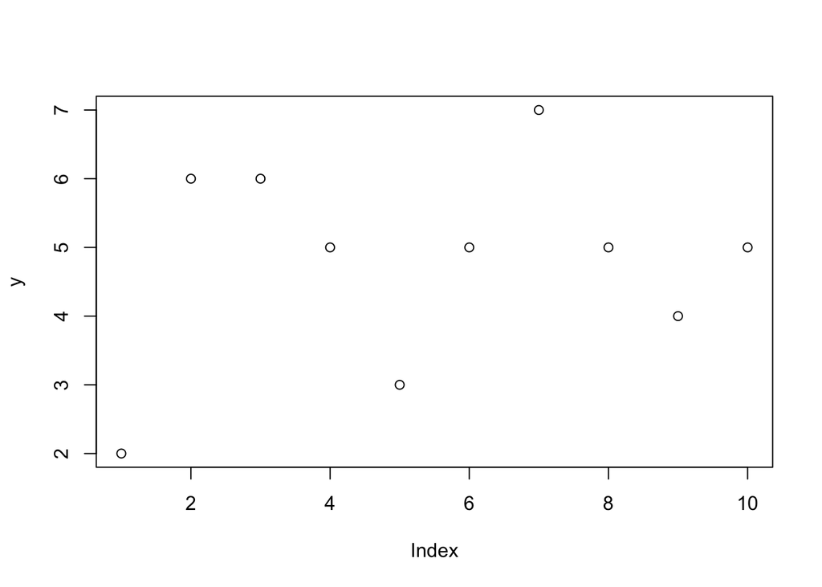

```r
set.seed(84343124)
y <- rpois(10, 5)
plot(y)
```

The log-posterior for the model is:

```r
log_post <- function(eta, y) {
  sum(y) * eta - (length(y) + 1) * exp(eta) - sum(lgamma(y + 1)) + eta
}
```

Get the first two derivatives too, and put them into a list:

```r
fn <- function(x) log_post(x, y)
gr <- function(x) numDeriv::grad(fn, x)
he <- function(x) numDeriv::hessian(fn, x)

ff <- list(fn = fn, gr = gr, he = he)
```

Use the `aghq` package with `k = 3`. Note that all `aghq::aghq::` is doing is normalising the posterior. We have already provided the exact posterior to it via `fn$ff`.

```r
quad <- aghq::aghq(ff = ff, k = 3, startingvalue = 0)
```

The result is of class `"aghq"`:

```r
class(quad)
```

```
## [1] "aghq"
```

```r
summary(quad)
```

```
## AGHQ on a 1 dimensional posterior with  3 quadrature points
##
## The posterior mode is: 1.494225
##
## The log of the normalizing constant/marginal likelihood is: -23.32123
##
## The covariance matrix used for the quadrature is...
##            [,1]
## [1,] 0.02040204
##
## Here are some moments and quantiles for the transformed parameter:
##
##            mean        sd     2.5%   median    97.5%
## theta1 1.483746 0.1424731 1.204479 1.482833 1.763169
```

We can plot the log marginal posterior for `theta1` in its normalised and unnormalised versions. The unnormalised version doesn’t require anything from `aghq`.

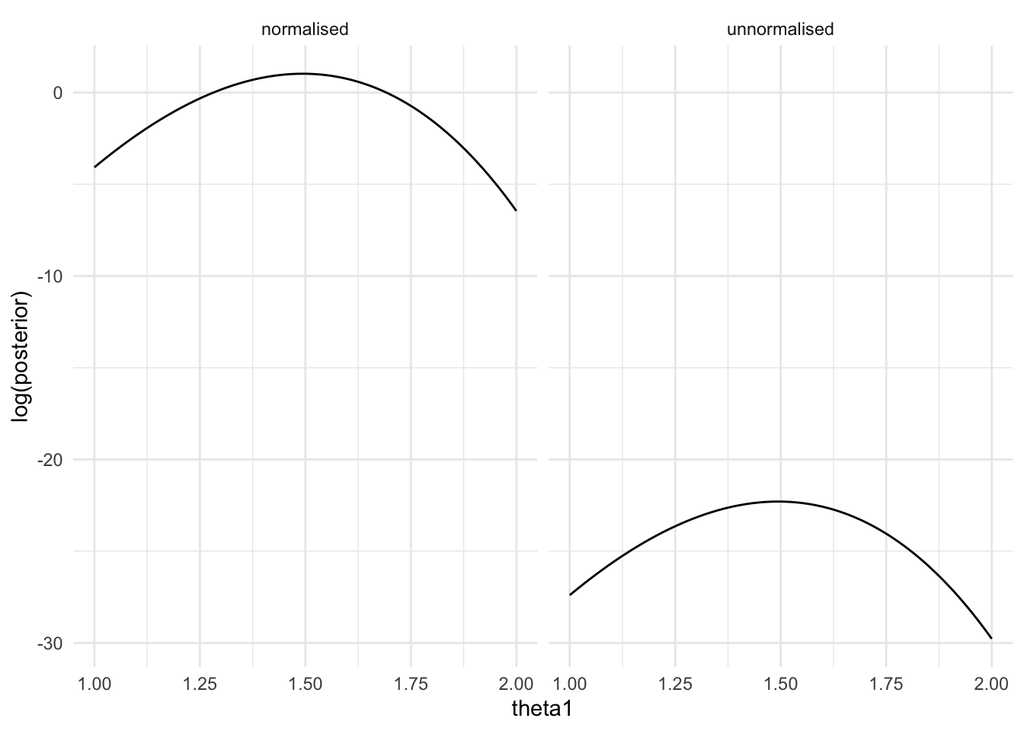

```r
data.frame(
  theta1 = seq(from = 1, to = 2, by = 0.01)
) %>%
  mutate(
    f_unnormalised = ff$fn(theta1),
    f_normalised = f_unnormalised - quad$normalized_posterior$lognormconst
  ) %>%
  pivot_longer(
    cols = starts_with("f"),
    names_sep = "_",
    names_to = c("function", "normalised")
  ) %>%
  ggplot(aes(x = theta1, y = value)) +
    geom_line() +
    facet_grid(~normalised) +
    labs(x = "theta1", y = "log(posterior)") +
    theme_minimal()
```

The contents of the `quad` object can be viewed using `str(quad)`. One part of the contents are the nodes and weights used for quadrature, which are:

```r
quad$normalized_posterior$nodesandweights
```

| theta1 | weights | logpost | logpost_normalized |
| --- | --- | --- | --- |
| 1.246826 | 0.2674344 | -23.67422 | -0.3529830 |
| 1.494225 | 0.2386907 | -22.29427 | 1.0269659 |
| 1.741624 | 0.2674344 | -23.92965 | -0.6084181 |

The logarithm of the normalising constant (should correspond to `logpost - logpost_normalised`, the difference between the two curves above):

```r
quad$normalized_posterior$lognormconst
```

```
## [1] -23.32123
```

The mode is as follows, which corresponds to the second node. For `k = 3`, and other odd numbers, the mode is included as a node.

```r
quad$optresults$mode
```

```
## [1] 1.494225
```

# More detailed background

## One dimensional example

Suppose we have
$$f(\theta) = \exp(-\frac{\theta^2}{2}),$$
which we would like to integrate over $\mathbb{R}$, i.e. $\int_{-\infty}^\infty f(\theta) \text{d}\theta$.

```r
f <- function(theta) {
  exp(-(theta^2) / 2)
}
```

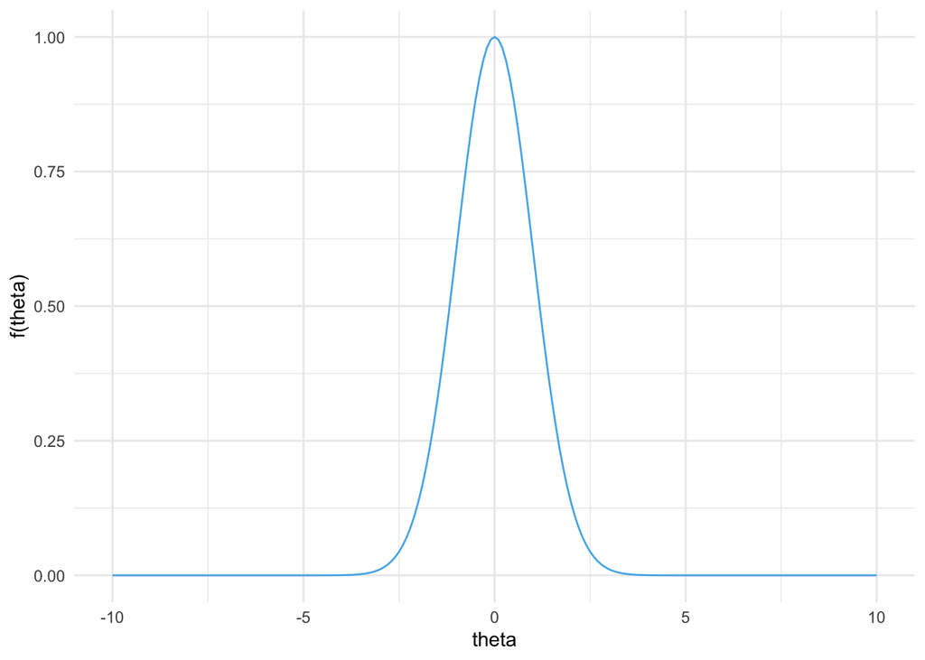

```r
plot <- data.frame(x = seq(from = -10, to = 10, by = 0.1)) %>%
  mutate(
    y = f(x)
  ) %>%
  ggplot(aes(x = x, y = y)) +
    geom_line(col = cbpalette[1]) +
    labs(x = "theta", y = "f(theta)") +
    theme_minimal()

plot
```

Going to do Gauss-Hermite quadrature with `k = 3` points:

```r
gg <- mvQuad::createNIGrid(1, "GHe", 3)
```

The positions of the nodes and their weights are:

```r
gg$nodes
```

```
##               [,1]
## [1,] -1.732051e+00
## [2,] -1.394817e-16
## [3,]  1.732051e+00
```

```r
gg$weights
```

```
##          [,1]
## [1,] 1.872321
## [2,] 1.671086
## [3,] 1.872321
```

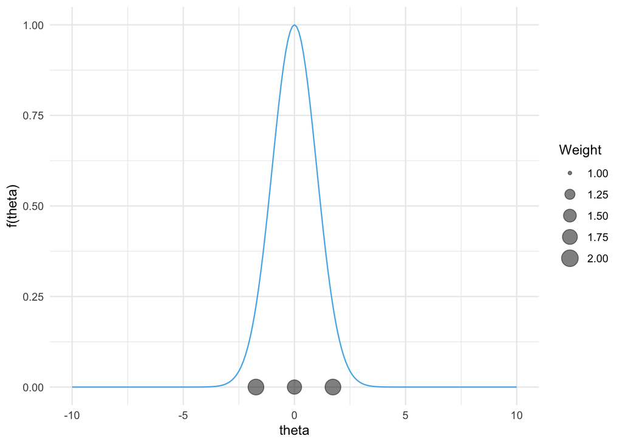

```r
plot <- plot +
  geom_point(
    data = data.frame(nodes = gg$nodes, weights = gg$weights, y = 0),
    aes(x = nodes, y = y, size = weights), alpha = 0.5
  ) +
  labs(size = "Weight") +
  scale_size_continuous(limits = c(1, 2))

plot
```

```r
ggsave(filename = "aghq-1d.pdf", plot = plot, height = 4, width = 6.25)
```

We can perform the quadrature using `mvQuad` via:

```r
mvQuad::quadrature(f, gg)
```

```
## [1] 2.506628
```

This isn’t doing anything fancy, it’s just multiplying the values at the nodes by the weights:

```r
sum(f(gg$nodes) * gg$weights)
```

```
## [1] 2.506628
```

Note that you can also use these functions to get the nodes and weights: `mvQuad::getNodes(gg)`, `mvQuad::getWeights(gg)`. The answer we get with `aghq` is exact in this case, as compared with the true answer of $\sqrt {2 \pi}$ because the target function is a log-quadratic:

```r
sqrt(2 * pi)
```

```
## [1] 2.506628
```

## Two dimensional example

What about a function in two dimensions? Take this one, where each marginal is the same as above:

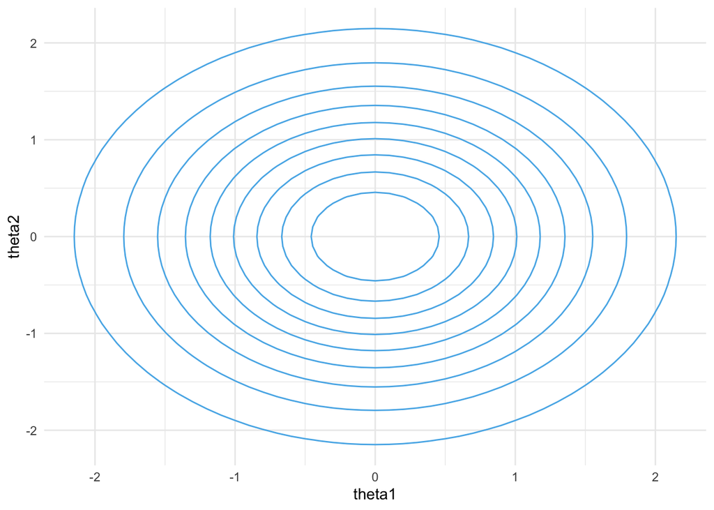

```r
f <- function(theta) {
  prod(exp(-(theta^2) / 2))
}

df <- expand.grid(
  theta1 = seq(-3, 3, by = 0.1),
  theta2 = seq(-3, 3, by = 0.1)
)

plot2 <- df %>%
  rowwise() %>%
  mutate(
    y = f(c(theta1, theta2))
  ) %>%
  ggplot() +
    geom_contour(aes(x = theta1, y = theta2, z = y), col = multi.utils::cbpalette()[1]) +
    theme_minimal()

plot2
```

Let’s create a quadrature grid again:

```r
gg2 <- mvQuad::createNIGrid(2, "GHe", 3)
gg2
```

```
## Grid for Numerical Integration
##  # dimensions: 2  # gridpoints: 9     used memory:704 bytes
##
## nD-Construction principle:  'product'
##  same quadrature rule for each dimension
##       type:  GHe
##       level:  3
##       initial domain:  -Inf Inf
```

The nodes and weights are:

```r
mvQuad::getNodes(gg2)
```

```
##                [,1]          [,2]
##  [1,] -1.732051e+00 -1.732051e+00
##  [2,] -1.394817e-16 -1.732051e+00
##  [3,]  1.732051e+00 -1.732051e+00
##  [4,] -1.732051e+00 -1.394817e-16
##  [5,] -1.394817e-16 -1.394817e-16
##  [6,]  1.732051e+00 -1.394817e-16
##  [7,] -1.732051e+00  1.732051e+00
##  [8,] -1.394817e-16  1.732051e+00
##  [9,]  1.732051e+00  1.732051e+00
```

```r
mvQuad::getWeights(gg2)
```

```
##           [,1]
##  [1,] 3.505588
##  [2,] 3.128809
##  [3,] 3.505588
##  [4,] 3.128809
##  [5,] 2.792527
##  [6,] 3.128809
##  [7,] 3.505588
##  [8,] 3.128809
##  [9,] 3.505588
```

This is equivalent to what can be achieved using the `gg` object from the one-dimensional example:

```r
expand.grid(mvQuad::getNodes(gg), mvQuad::getNodes(gg))
```

| Var1 | Var2 |
| --- | --- |
| -1.732051e+00 | -1.732051e+00 |
| -1.394817e-16 | -1.732051e+00 |
| 1.732051e+00 | -1.732051e+00 |
| -1.732051e+00 | -1.394817e-16 |
| -1.394817e-16 | -1.394817e-16 |
| 1.732051e+00 | -1.394817e-16 |
| -1.732051e+00 | 1.732051e+00 |
| -1.394817e-16 | 1.732051e+00 |
| 1.732051e+00 | 1.732051e+00 |

```r
cbind(apply(expand.grid(mvQuad::getWeights(gg), mvQuad::getWeights(gg)), 1, prod))
```

```
##           [,1]
##  [1,] 3.505588
##  [2,] 3.128809
##  [3,] 3.505588
##  [4,] 3.128809
##  [5,] 2.792527
##  [6,] 3.128809
##  [7,] 3.505588
##  [8,] 3.128809
##  [9,] 3.505588
```

What do these nodes and weights look like on the plot?

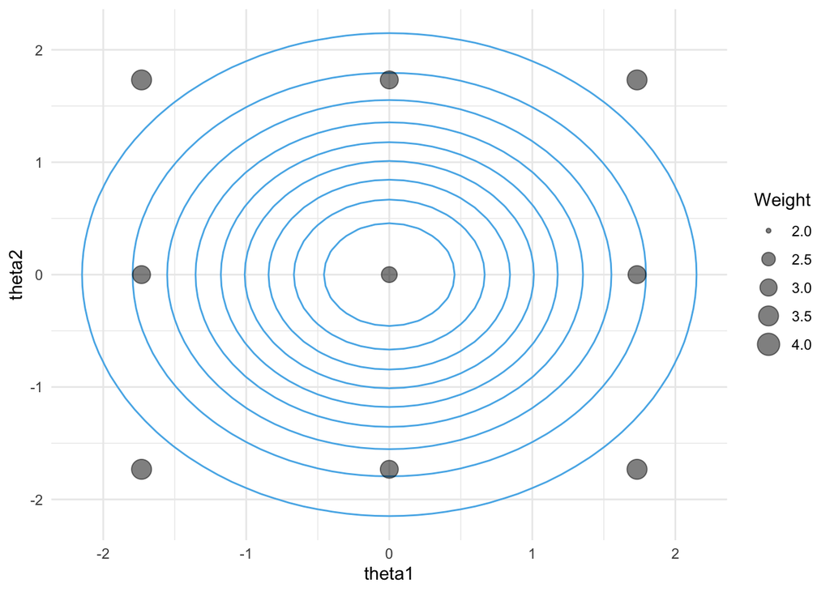

```r
plot2 <- plot2 +
  geom_point(
    data = mvQuad::getNodes(gg2) %>%
            as.data.frame() %>%
            mutate(weights = mvQuad::getWeights(gg2)),
    aes(x = V1, y = V2, size = weights),
    alpha = 0.5
  ) +
  labs(col = "f(theta1, theta2)", size = "Weight") +
  scale_size_continuous(limits = c(2, 4))

plot2
```

```r
ggsave(filename = "aghq-2d.pdf", plot = plot2, height = 4, width = 6.25)
```

Ok! So now let’s use `mvQuad` to do the quadrature:

```r
#' Need f to be defined like this for some reason, can probably be fixed
f <- function(x) {
  apply(x, 1, function(y) prod(exp(-(y^2) / 2)))
}

mvQuad::quadrature(f, gg2)
```

```
## [1] 6.283185
```

Again, in this case the quadrature is exact

```r
2 * pi
```

```
## [1] 6.283185
```

See Definition 1 of the [theory paper](https://arxiv.org/pdf/2102.06801.pdf) for more on when the integration will be exact.

## Gauss-Hermite Quadrature

Define the Hermite polynomial with $k = 3$ as:

```r
Hk <- as.function(mpoly::hermite(3, kind = "he"))
```

```
## f(.) with . = x
```

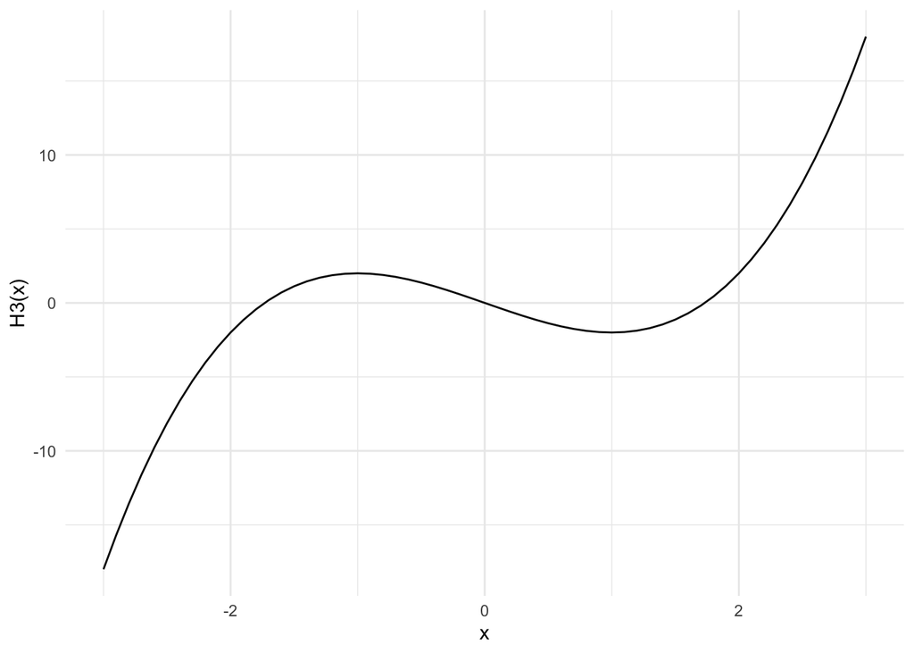

```r
plot <- data.frame(x = seq(-3, 3, by = 0.1)) %>%
  mutate(Hkx = Hk(x)) %>%
  ggplot(aes(x = x, y = Hkx)) +
    geom_line() +
    labs(x = "x", y = "H3(x)") +
    theme_minimal()

plot
```

In Gauss-Hermite quadrature, we pick nodes which are zeroes of the Hermite polynomial:

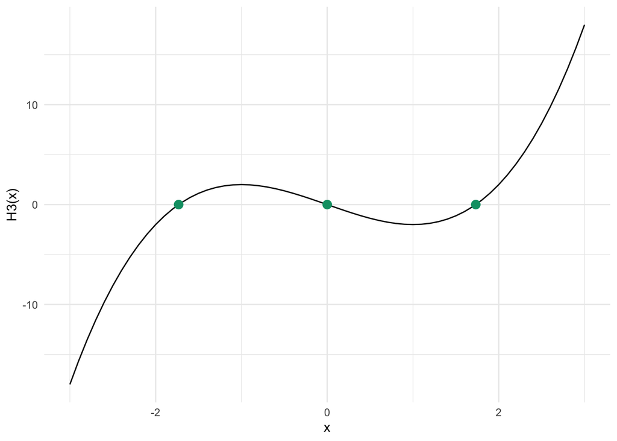

```r
nn <- mvQuad::getNodes(gg)

plot +
  geom_point(
    data = data.frame(x = nn, y = Hk(nn)), aes(x = x, y = y),
    col = cbpalette[2], size = 3
  )
```

Note that these nodes are chosen *only* based on the Hermite polynomial. The function to be integrated has not played any role in their choice! This is probably not a good idea. So in adaptive quadrature, the function plays some role in how the points are chosen. Specifically in adaptive GHQ it’s done by scaling the nodes and weights by the mode and curvature at the mode of the function to be integrated. Imagine we have some fake values for the mode `theta_hat` and curvature at the mode `theta_hess` as follows:

```r
theta_hat <- c(2, 3)
theta_hess <- matrix(c(3, 1, 1, 5), nrow = 2, ncol = 2)
theta_hess_inv <- solve(theta_hess)
```

Then the rescaling can be done with `mvQuad` easily via:

```r
k <- 3
int_grid_software <- mvQuad::createNIGrid(2, "GHe", k)
mvQuad::rescale(int_grid_software, m = theta_hat, C = theta_hess_inv, dec.type = 2)
```

All that is doing manually to the nodes is:

```r
int_grid_manual <- mvQuad::createNIGrid(2, "GHe", k)
nn_rescaled <- mvQuad::getNodes(int_grid_manual) %*% chol(theta_hess_inv)
nn_rescaled[, 1] <- nn_rescaled[, 1] + theta_hat[1]
nn_rescaled[, 2] <- nn_rescaled[, 2] + theta_hat[2]
```

Or to the weights is:

```r
mvQuad::getWeights(int_grid_software)
```

```
##            [,1]
##  [1,] 0.9369077
##  [2,] 0.8362094
##  [3,] 0.9369077
##  [4,] 0.8362094
##  [5,] 0.7463342
##  [6,] 0.8362094
##  [7,] 0.9369077
##  [8,] 0.8362094
##  [9,] 0.9369077
```

```r
ww_rescaled <- mvQuad::getWeights(int_grid_manual) * det(chol(theta_hess_inv))
```

# Tomato disease example

Ok, let’s now move on to an example with real data.

```r
data("tswv", package = "EpiILMCT")
dat <- tswv$tswvsir
dat$epidat <- dat$epidat[order(dat$epidat[, 4]), ]
I <- dat$epidat[, 4]
R <- dat$epidat[, 2]
infected <- !is.infinite(I)

datlist <- list(
  D = as.matrix(dist(dat$location[dat$epidat[, 1], ])),
  I = I,
  R = R,
  infected = as.numeric(infected[infected])
)
```

```r
precompile()
```

```
## Removing: libTMB.cpp libTMB.o libTMBdbg.cpp libTMBomp.cpp
```

```
## Precompilation sources generated
```

```r
compile("disease.cpp")
```

```
## [1] 0
```

```r
dyn.load(dynlib("disease"))
```

Create the unnormalised negative log posterior using `TMB::MakeADFun` as follows:

```r
ff <- TMB::MakeADFun(
  data = datlist,
  parameters = list(theta1 = 0, theta2 = 0),
  DLL = "disease",
  ADreport = FALSE,
  silent = TRUE
)
```

Perform AGHQ with $k = 7$, starting optimisation from $(0, 0)$:

```r
tm <- Sys.time()

tmp <- capture.output(
  ilm_quadrature <- aghq::aghq(ff, 7, c(0, 0))
)

runtime <- difftime(Sys.time(), tm, units = "secs")
```

The time this took was:

```r
runtime
```

```
## Time difference of 0.1223681 secs
```

Note that as there are $k = 7$ quadrature points per dimension, in total there are $7^2 = 49$:

```r
summary(ilm_quadrature)
```

```
## AGHQ on a 2 dimensional posterior with  7 7 quadrature points
##
## The posterior mode is: -4.38672 0.2909931
##
## The log of the normalizing constant/marginal likelihood is: -1087.572
##
## The covariance matrix used for the quadrature is...
##            [,1]       [,2]
## [1,] 0.03494285 0.01960776
## [2,] 0.01960776 0.01205820
##
## Here are some moments and quantiles for the transformed parameter:
##
##              mean        sd        2.5%     median      97.5%
## theta1 -4.4392970 0.1997867 -4.88217078 -4.4274227 -4.0933793
## theta2  0.2583451 0.1207060 -0.01654348  0.2670827  0.4616635
```

The parameters $\alpha = \exp(\theta_1)$ and $\beta = \exp(\theta_2)$, which we can compute summaries for as follows:

```r
ilm_means <- aghq::compute_moment(ilm_quadrature$normalized_posterior, function(x) exp(x))
names(ilm_means) <- c("alpha", "beta")
ilm_means
```

```
##    alpha     beta
## 0.012035 1.304030
```

You can calculate other moments using the `ff`, `gg` or `nn` arguments to `aghq::compute_moment`. There is also some nuance to the argument `method`, either `reuse` or `correct`. `reuse` uses the previously computed AGHQ nodes and weights. `correct` recomputes the mode and curvature for the product of $g$ and the posterior; it has convergence proofs, but is a bit slower and can be unstable.

We can also compute quantiles using the function `aghq::compute_quantiles`, where `q` is a vector of numeric values in $(0, 1)$.

```r
my_q <- c(0.025, 0.1, 0.5, 0.9, 0.975)
```

For $\alpha$:

```r
exp(aghq::compute_quantiles(ilm_quadrature$marginals[[1]], q = my_q))
```

```
##       2.5%        10%        50%        90%      97.5%
## 0.00758054 0.00904698 0.01194524 0.01503700 0.01668276
```

For $\beta$:

```r
exp(aghq::compute_quantiles(ilm_quadrature$marginals[[2]], q = my_q)) # beta
```

```
##      2.5%       10%       50%       90%     97.5%
## 0.9835926 1.1021213 1.3061485 1.4952597 1.5867113
```